# metaHelper_analysis

## Setting up Environment

This analysis requires the packages tidyverse, brms and tidbayes.

```r
set.seed(1)

library("broom.mixed")
library("tidyverse")
library("brms")
library("tidybayes")
dat_result <- read.csv("dat_result.csv", stringsAsFactors = FALSE)

dat_result <- dat_result %>%
  mutate(group = gsub("Intervention", "metaHelper", group))

# this dataframe is used for visualization only. It provides the background colors for the exploratory plots.
group_shading_dat <- data.frame(
  ID = c(0, 0),
  result = c(0,0),
  x_min = c(1, 1),
  x_max = c(1, 1),
  y_min = c(0, 0),
  y_max = c(0, 0),
  Group = c("metaHelper", "Control")
)
```

## Exploratory analysis

### Correct answers

Show the frequency of answers

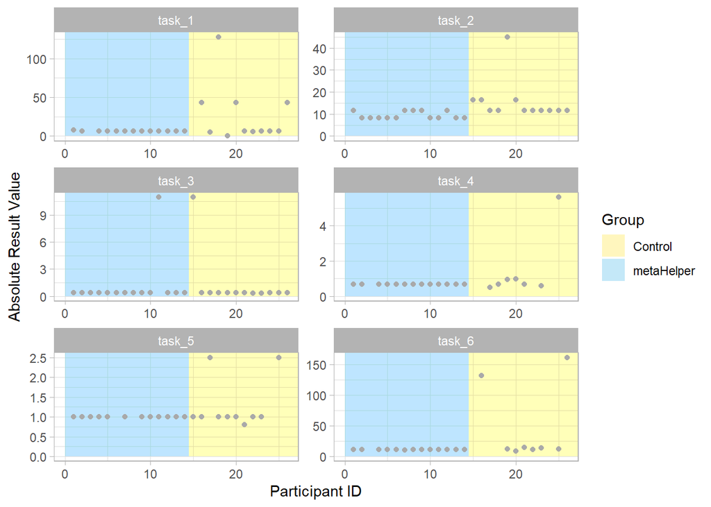

```r
dat_result %>%
  ggplot(aes(x = ID, y = abs(result))) +
  geom_rect(aes(xmin = min(ID), xmax = max(ID), ymin = 0, ymax = max(result), fill = group),  alpha = 0.2) +
  #first geom_rect is just used to create the legend
  geom_rect(data = group_shading_dat, aes(xmin = x_min, xmax = x_max, ymin = y_min, ymax = y_max, fill = Group),  alpha = 0.2) +
  geom_rect(xmin = 0, xmax = 14.5, ymin = 0, ymax = 500, fill = "#5BC0EB",  alpha = 0.02) +
  geom_rect(xmin = 14.5, xmax = 500, ymin = 0, ymax = 500, fill = "#FDE74C",  alpha = 0.02) +
  geom_point(color = "darkgray") +
  xlab("Participant ID") +
  ylab("Absolute Result Value") +
  facet_wrap(~task, scales = "free", ncol = 2) +
  scale_fill_manual(name = "Group",
                    values = c("#FDE74C", "#5BC0EB")) +
  theme_light()
```

Which were correct?

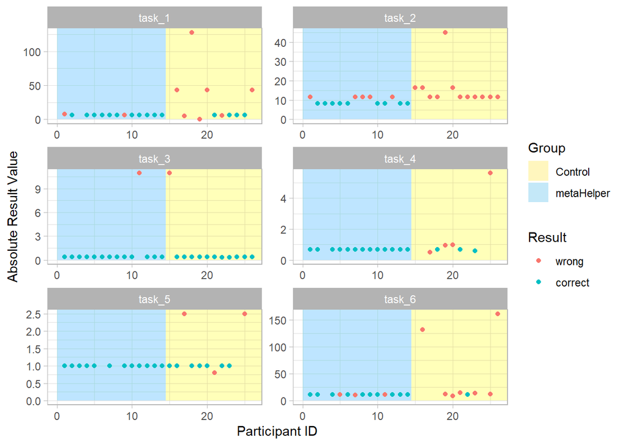

```r
dat_result  %>%
  mutate(result_correct = as_factor(result_correct) %>%
           recode("0" = "wrong", "1" = "correct")) %>%
  ggplot(aes(x = ID, y = abs(result))) +
  geom_rect(aes(xmin = min(ID), xmax = max(ID), ymin = 0, ymax = max(result), fill = group),  alpha = 0.2) +
  #first geom_rect is just used to create the legend
  geom_rect(data = group_shading_dat, aes(xmin = x_min, xmax = x_max, ymin = y_min, ymax = y_max, fill = Group),  alpha = 0.2) +
  geom_rect(xmin = 0, xmax = 14.5, ymin = 0, ymax = 500, fill = "#5BC0EB",  alpha = 0.02) +
  geom_rect(xmin = 14.5, xmax = 500, ymin = 0, ymax = 500, fill = "#FDE74C",  alpha = 0.02) +
  geom_point(aes(color = result_correct)) +
  xlab("Participant ID") +
  ylab("Absolute Result Value") +
  labs(color = "Result") +
  facet_wrap(~task, scales = "free", ncol = 2) +
  scale_fill_manual(name = "Group",
                    values = c("#FDE74C", "#5BC0EB")) +
  theme_light()
```

```r
ggsave("Exploratory_Plot_Result.png", width = 10, height = 12, dpi = 600)
```

# Statistical modelling - Correctness

## Task 1

Percentage correct control = 42.3

Percentage correct intervention = 70.5

Effect intervention logit = 1.1832716

Effect intervention logit lower = -0.0774978

Effect intervention logit lower = 2.4886168

## Task 2

Percentage correct control = 14.8

Percentage correct intervention = 52.5

Effect intervention logit = 1.8533976

Effect intervention logit lower = 0.5255242

Effect intervention logit lower = 3.260873

## Task 3

Percentage correct control = 90

Percentage correct intervention = 90.5

Effect intervention logit = 0.0565218

Effect intervention logit lower = -1.4912329

Effect intervention logit lower = 1.6034962

## Task 4

Percentage correct control = 38.9

Percentage correct intervention = 80.2

Effect intervention logit = 1.8513541

Effect intervention logit lower = 0.5725933

Effect intervention logit lower = 3.178263

## Task 5

Percentage correct control = 63.9

Percentage correct intervention = 79.6

Effect intervention logit = 0.7887643

Effect intervention logit lower = -0.5429974

Effect intervention logit lower = 2.1181092

## Task 6

Percentage correct control = 21.6

Percentage correct intervention = 60.3

Effect intervention logit = 1.7064317

Effect intervention logit lower = 0.4131683

Effect intervention logit lower = 3.051474

## All Tasks combined

```r
summary(result_all)$fixed["groupmetaHelper", ]
```

```
                Estimate Est.Error l-95% CI u-95% CI     Rhat Bulk_ESS Tail_ESS
groupmetaHelper 2.530793 0.4594837 1.664841 3.478618 1.000356 16219.07 12751.38
```

Overall probability for solution in control = 0.3109637

Overall probability for solution in intervention = 0.8500732 Overall probability for solution in intervention Lower Limit = 0.7045841 Overall probability for solution in intervention Lower Limit = 0.9360161

```r
summary(result_all)$fixed
```

```
                  Estimate Est.Error  l-95% CI  u-95% CI     Rhat  Bulk_ESS
Intercept       -0.7956177 0.6058113 -2.054223 0.3849062 1.000629  6018.359
groupmetaHelper  2.5307928 0.4594837  1.664841 3.4786182 1.000356 16219.065
                 Tail_ESS
Intercept        7862.599
groupmetaHelper 12751.376
```

```r
summary(result_all)$fixed %>%
  data.frame() %>%
  mutate(across(Estimate:Rhat, round, digits = 2),
         across(Bulk_ESS:Tail_ESS, round, digits = 0)) %>%
  write.csv("result_correctness.csv")
```

## Posterior Samples

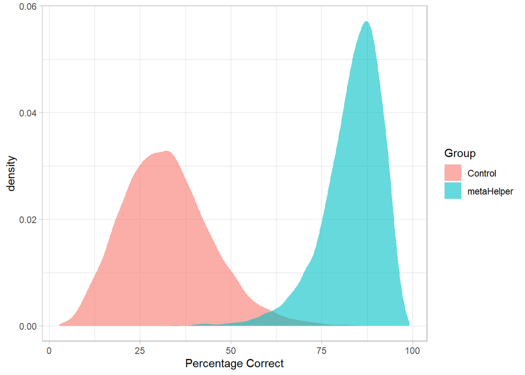

```r
posterior_samples <- as_draws_array(result_all)
tidy_samples <- tidy_draws(posterior_samples)

tidy_samples %>%
  mutate(metaHelper = logit2prob(b_Intercept + b_groupmetaHelper) *100,
         Control = logit2prob(b_Intercept) * 100) %>%
  select(metaHelper, Control) %>%
  pivot_longer(everything(), names_to = "Group") %>%
  ggplot(aes(x = value, fill = Group)) +
  geom_density(alpha = 0.6, color = NA) +
  xlab("Percentage Correct") +
  theme_light()
```

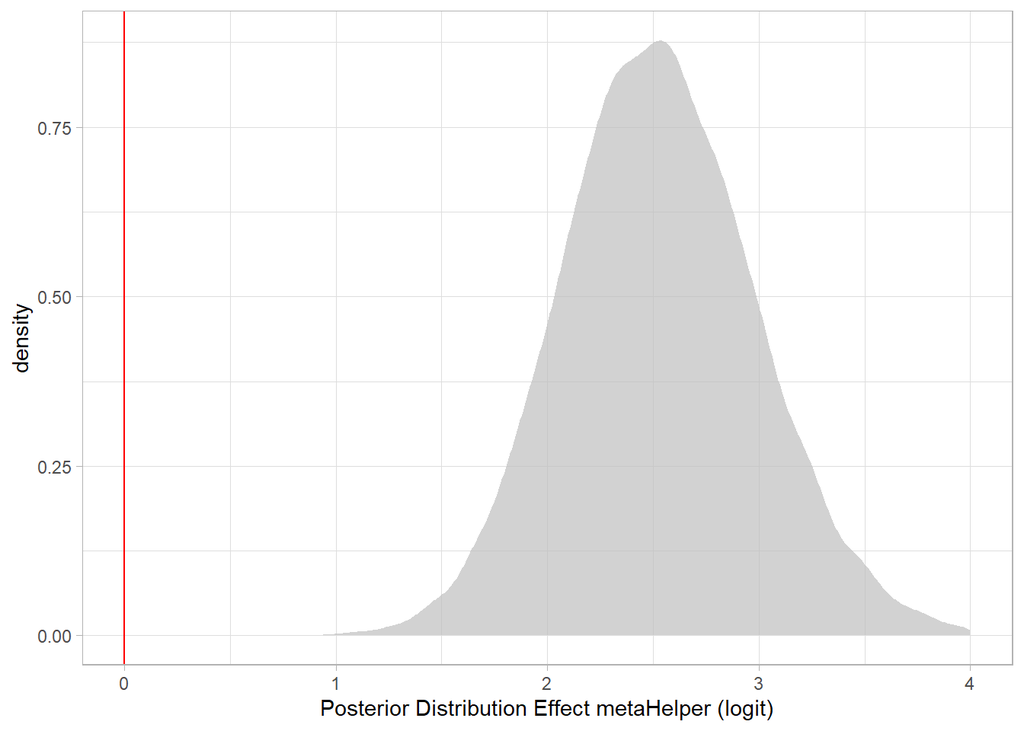

```r
tidy_samples %>%
  mutate(metaHelper = b_Intercept + b_groupmetaHelper,
         Control = b_Intercept) %>%
  ggplot(aes(x = b_groupmetaHelper)) +
  xlim(c(0, 4)) +
  geom_density(fill = "gray", alpha = 0.7, color = NA) +
  theme_light() +
  xlab("Posterior Distribution Effect metaHelper (logit)") +
  geom_vline(xintercept = 0, color = "red")
```

## Model Fit

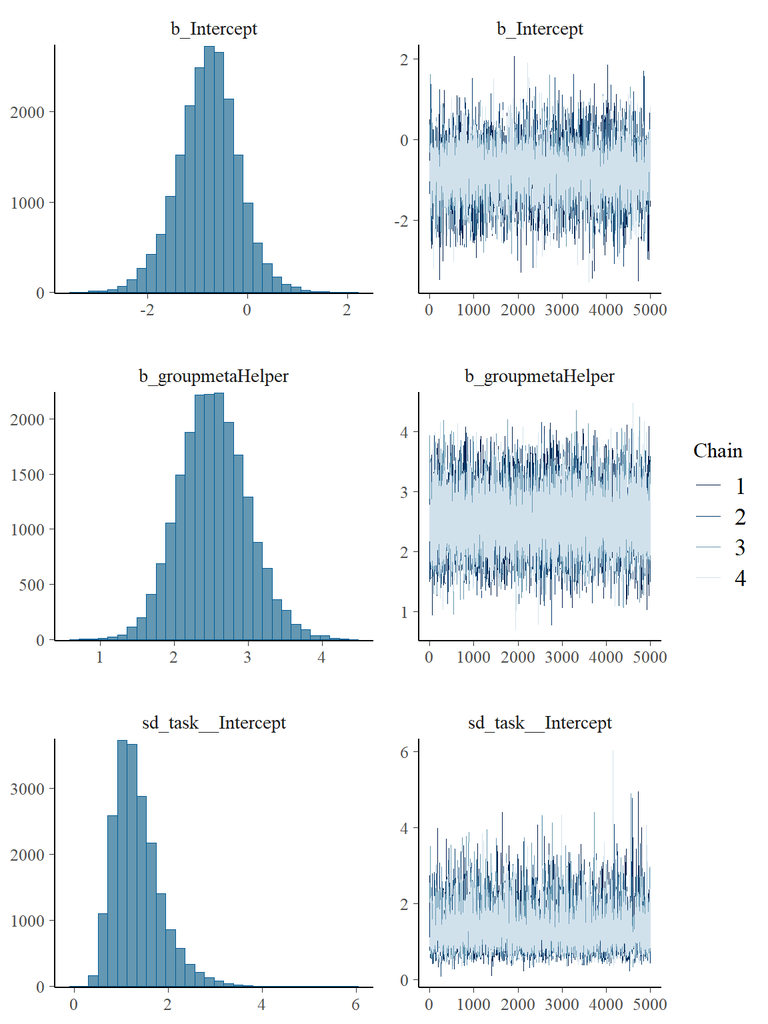

```r
plot(result_all)
```

# Statistical Modelling - Time

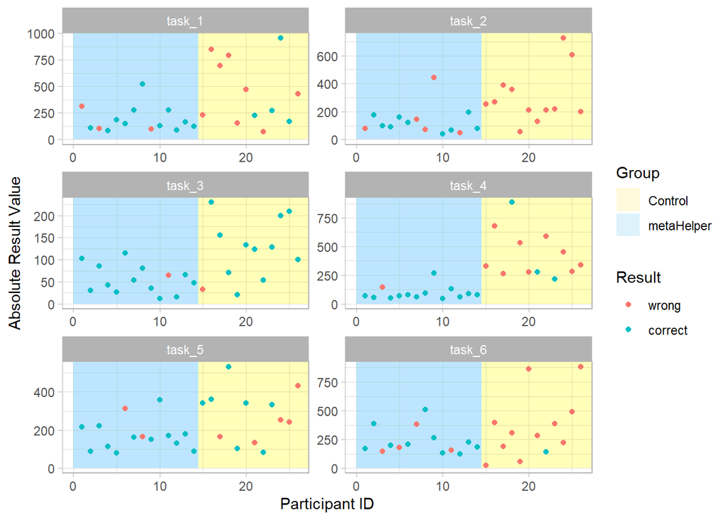

```r
group_shading_dat$time <- 0

dat_result %>%
  mutate(result_correct = as_factor(result_correct) %>%
           recode("0" = "wrong", "1" = "correct")) %>%
  ggplot(aes(x = ID, y = time)) +
  #first geom_rect is just used to create the legend
  geom_rect(data = group_shading_dat, aes(xmin = x_min, xmax = x_max, ymin = y_min, ymax = y_max, fill = Group),  alpha = 0.2) +
  geom_rect(xmin = 0, xmax = 14.5, ymin = 0, ymax = 5000, fill = "#5BC0EB",  alpha = 0.02) +
  geom_rect(xmin = 14.5, xmax = 500, ymin = 0, ymax = 5000, fill = "#FDE74C",  alpha = 0.02) +
  geom_point(aes(color = result_correct)) +
  facet_wrap(~task, scales = "free", ncol = 2) +
  xlab("Participant ID") +
  ylab("Absolute Result Value") +
  labs(color = "Result") +
  scale_fill_manual(name = "Group",
                    values = c("#FDE74C", "#5BC0EB")) +

  theme_light()
```

```r
ggsave("Exploratory_Plot_Result_Time.png", width = 10, height = 12, dpi = 600)
```

## Task 1

```r
summary(result_1_time)$fixed
```

```
                 Estimate Est.Error  l-95% CI  u-95% CI     Rhat Bulk_ESS
Intercept        438.7108  6.555006  425.8168  451.6472 1.000432 18799.11
groupmetaHelper -247.9174  8.828525 -265.2360 -230.6706 1.000099 19061.52
                Tail_ESS
Intercept       13817.26
groupmetaHelper 14075.86
```

## Task 2

```r
summary(result_2_time)$fixed
```

```
                 Estimate Est.Error  l-95% CI  u-95% CI      Rhat Bulk_ESS
Intercept        300.2941  5.077130  290.3301  310.2647 0.9999907 19989.16
groupmetaHelper -169.7095  6.929275 -183.3242 -156.0393 1.0002015 20313.97
                Tail_ESS
Intercept       14715.91
groupmetaHelper 14816.60
```

## Task 3

```r
summary(result_3_time)$fixed
```

```
                 Estimate Est.Error  l-95% CI  u-95% CI     Rhat Bulk_ESS
Intercept       121.29706  2.453284 116.49102 126.09388 1.000674 19187.24
groupmetaHelper -65.68158  3.376880 -72.25532 -59.08339 1.000171 19167.92
                Tail_ESS
Intercept       14135.07
groupmetaHelper 13622.76
```

## Task 4

```r
summary(result_4_time)$fixed
```

```
                 Estimate Est.Error  l-95% CI  u-95% CI     Rhat Bulk_ESS
Intercept        423.5661  4.941849  413.9127  433.3235 1.000155 18932.36
groupmetaHelper -328.8692  6.668480 -341.9028 -315.9085 1.000155 19137.34
                Tail_ESS
Intercept       13763.15
groupmetaHelper 14898.96
```

## Task 5

```r
summary(result_5_time)$fixed
```

```
                 Estimate Est.Error  l-95% CI  u-95% CI     Rhat Bulk_ESS
Intercept        275.8284  4.102887  267.8259 283.77539 1.000179 19285.68
groupmetaHelper -101.7353  5.502398 -112.4789 -90.93022 1.000358 19383.71
                Tail_ESS
Intercept       15056.34
groupmetaHelper 14573.61
```

## Task 6

```r
summary(result_6_time)$fixed
```

```
                 Estimate Est.Error  l-95% CI  u-95% CI     Rhat Bulk_ESS
Intercept        352.7491  6.195178  340.6404  364.9502 1.000043 19813.94
groupmetaHelper -117.7070  8.424186 -134.0240 -101.2519 1.000300 19619.98
                Tail_ESS
Intercept       14605.11
groupmetaHelper 14376.11
```

## All Tasks

```r
summary(result_time_all)
```

```
 Family: gaussian
  Links: mu = identity; sigma = identity
Formula: time ~ 1 + (1 | task) + group
   Data: dat_result (Number of observations: 156)
  Draws: 4 chains, each with iter = 10000; warmup = 5000; thin = 1;
         total post-warmup draws = 20000

Multilevel Hyperparameters:
~task (Number of levels: 6)
              Estimate Est.Error l-95% CI u-95% CI Rhat Bulk_ESS Tail_ESS
sd(Intercept)     0.01      0.01     0.00     0.04 1.00    20532    10849

Regression Coefficients:
                Estimate Est.Error l-95% CI u-95% CI Rhat Bulk_ESS Tail_ESS
Intercept         296.72     19.61   258.15   334.58 1.00    28918    15983
groupmetaHelper  -132.50     24.93  -180.20   -83.02 1.00    27288    15543

Further Distributional Parameters:
      Estimate Est.Error l-95% CI u-95% CI Rhat Bulk_ESS Tail_ESS
sigma   178.13     10.35   159.26   199.89 1.00    26846    15716

Draws were sampled using sampling(NUTS). For each parameter, Bulk_ESS
and Tail_ESS are effective sample size measures, and Rhat is the potential
scale reduction factor on split chains (at convergence, Rhat = 1).
```

```r
summary(result_time_all)$fixed %>%
  data.frame() %>%
  mutate(across(Estimate:Rhat, round, digits = 2),
         across(Bulk_ESS:Tail_ESS, round, digits = 0)) %>%
  write.csv("result_time.csv")
```

### Posterior Samples

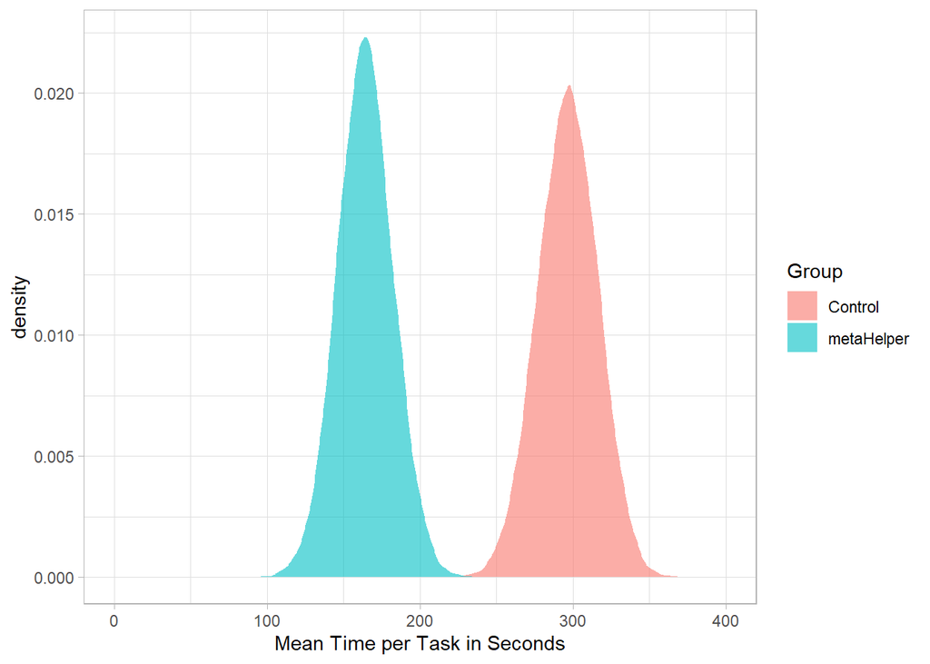

```r
posterior_samples <- as_draws_array(result_time_all)
tidy_samples <- tidy_draws(posterior_samples)

tidy_samples %>%
  mutate(metaHelper = b_Intercept + b_groupmetaHelper,
         Control = b_Intercept) %>%
  select(metaHelper, Control) %>%
  pivot_longer(everything(), names_to = "Group") %>%
  ggplot(aes(x = value, fill = Group)) +
  xlim(c(0, 400)) +
  geom_density(alpha = 0.6, color = NA) +
  xlab("Mean Time per Task in Seconds") +
  theme_light()
```

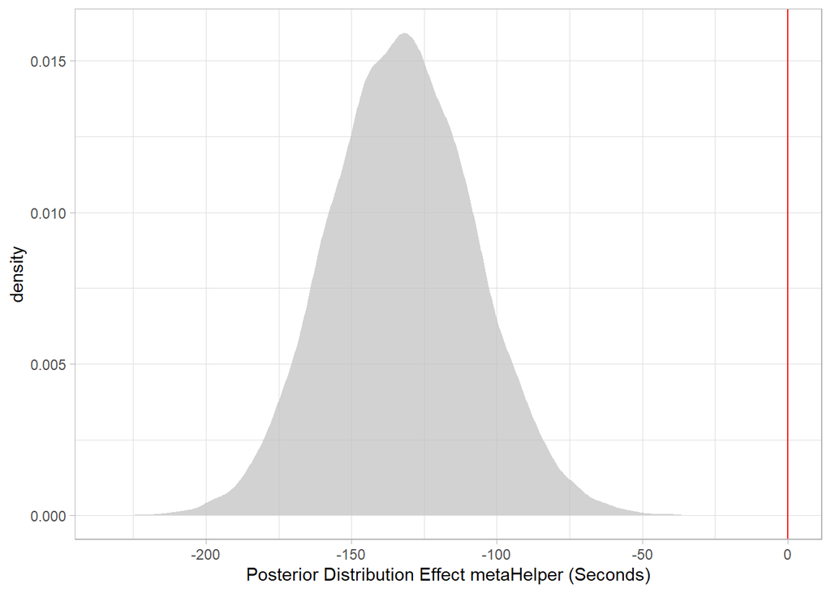

```r
ggsave("Result Time.png", width = 10, height = 5, dpi = 600)


tidy_samples %>%
  mutate(metaHelper = b_Intercept + b_groupmetaHelper,
         Control = b_Intercept) %>%
  ggplot(aes(x = b_groupmetaHelper)) +
  geom_density(fill = "gray", alpha = 0.7, color = NA) +
  theme_light() +
  xlab("Posterior Distribution Effect metaHelper (Seconds)") +
  geom_vline(xintercept = 0, color = "red")
```

### Model Fit

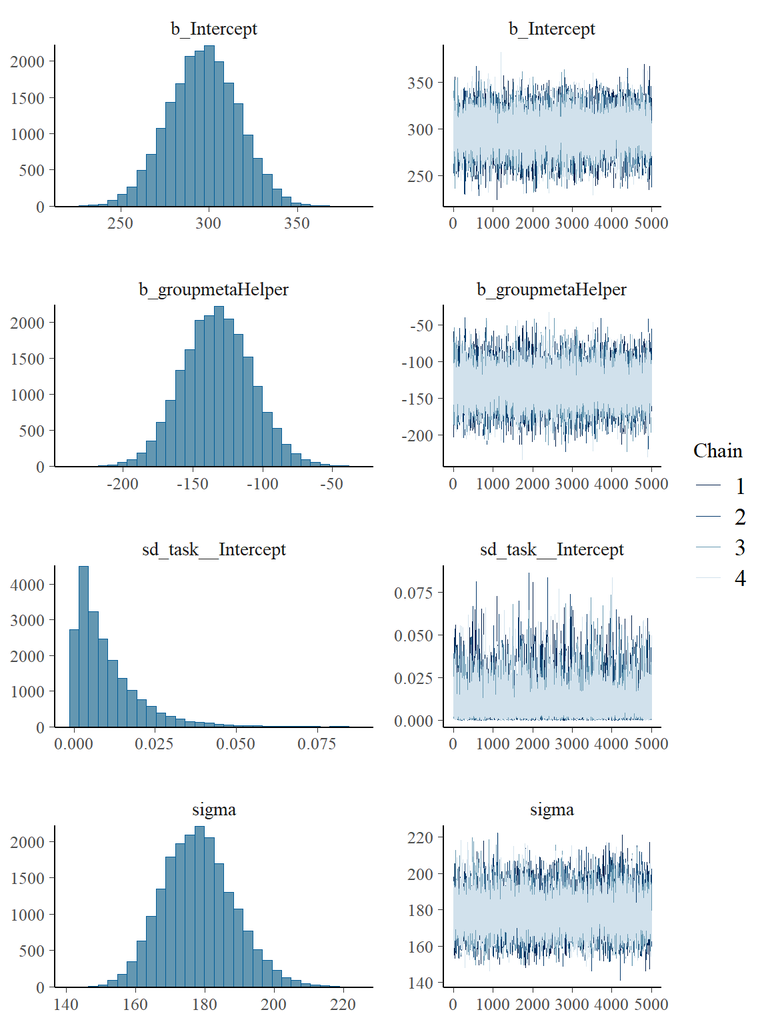

```r
plot(result_time_all)
```

## All Tasks - Taking Correctness into account

```r
summary(result_time_all_c)
```

```
 Family: gaussian
  Links: mu = identity; sigma = identity
Formula: time ~ 1 + (1 | task) + group * result_correct
   Data: dat_result (Number of observations: 156)
  Draws: 4 chains, each with iter = 10000; warmup = 5000; thin = 1;
         total post-warmup draws = 20000

Multilevel Hyperparameters:
~task (Number of levels: 6)
              Estimate Est.Error l-95% CI u-95% CI Rhat Bulk_ESS Tail_ESS
sd(Intercept)     0.01      0.01     0.00     0.04 1.00    20152     9524

Regression Coefficients:
                               Estimate Est.Error l-95% CI u-95% CI Rhat
Intercept                        323.70     22.44   279.54   367.63 1.00
groupmetaHelper                  -95.70     31.55  -158.00   -33.68 1.00
result_correct                   -55.80     29.95  -114.61     2.93 1.00
groupmetaHelper:result_correct   -30.41     35.35   -99.69    39.00 1.00
                               Bulk_ESS Tail_ESS
Intercept                         27534    17233
groupmetaHelper                   22198    15991
result_correct                    22572    15351
groupmetaHelper:result_correct    18745    15159

Further Distributional Parameters:
      Estimate Est.Error l-95% CI u-95% CI Rhat Bulk_ESS Tail_ESS
sigma   175.74     10.16   157.15   196.87 1.00    26678    15847

Draws were sampled using sampling(NUTS). For each parameter, Bulk_ESS
and Tail_ESS are effective sample size measures, and Rhat is the potential
scale reduction factor on split chains (at convergence, Rhat = 1).
```

### Posterior Samples

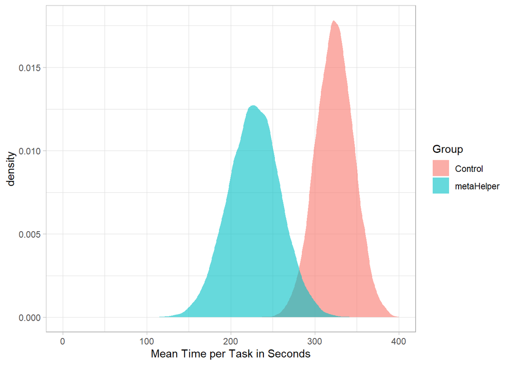

```r
posterior_samples <- as_draws_array(result_time_all_c)
tidy_samples <- tidy_draws(posterior_samples)

tidy_samples %>%
  mutate(metaHelper = b_Intercept + b_groupmetaHelper,
         Control = b_Intercept) %>%
  select(metaHelper, Control) %>%
  pivot_longer(everything(), names_to = "Group") %>%
  ggplot(aes(x = value, fill = Group)) +
  xlim(c(0, 400)) +
  geom_density(alpha = 0.6, color = NA) +
  xlab("Mean Time per Task in Seconds") +
  theme_light()
```

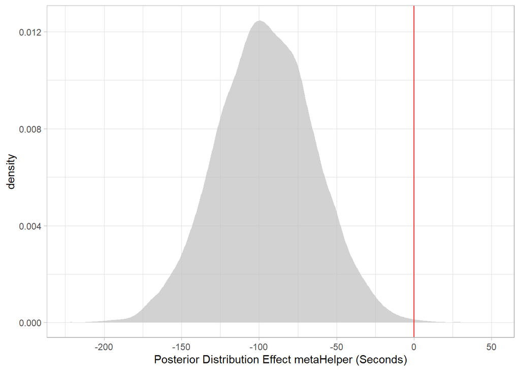

```r
tidy_samples %>%
  mutate(metaHelper = b_Intercept + b_groupmetaHelper,
         Control = b_Intercept) %>%
  ggplot(aes(x = b_groupmetaHelper)) +
  geom_density(fill = "gray", alpha = 0.7, color = NA) +
  theme_light() +
  xlab("Posterior Distribution Effect metaHelper (Seconds)") +
  geom_vline(xintercept = 0, color = "red")
```

### Model Fit

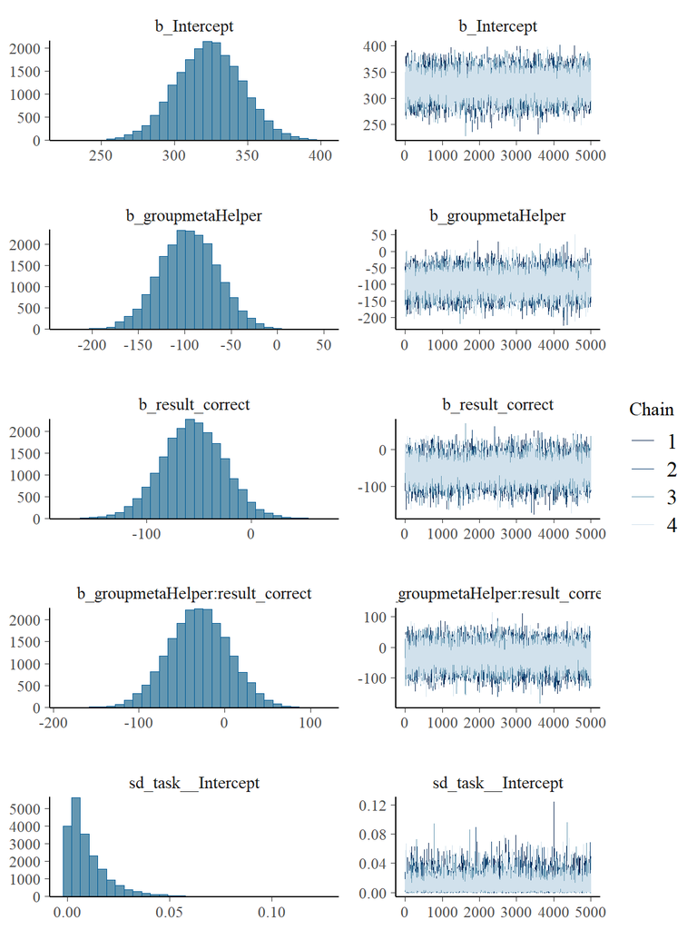

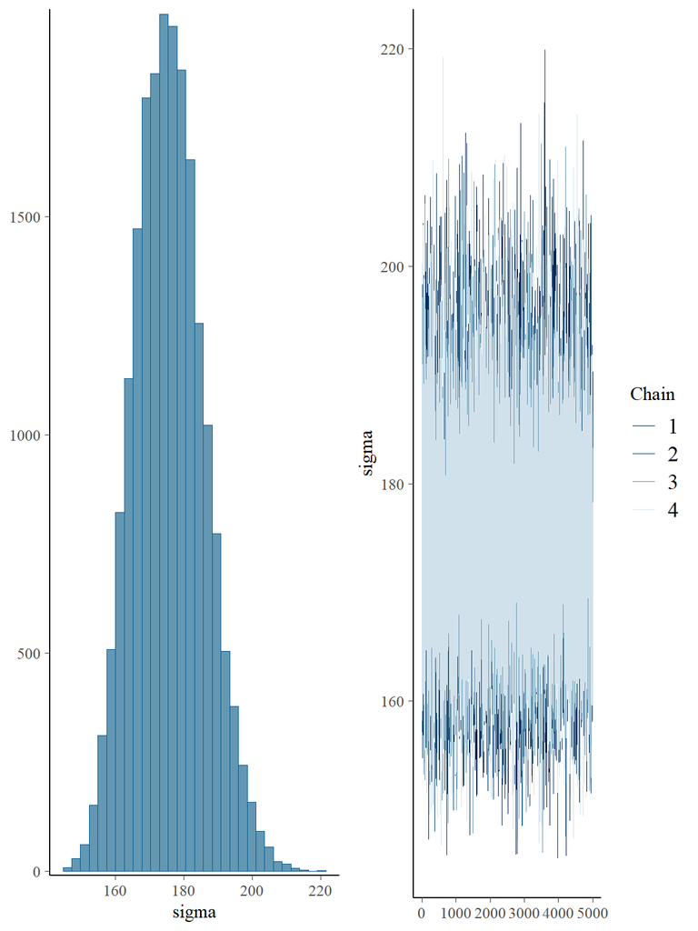

```r
plot(result_time_all_c, out.extra='stdout')
```

```r
summary(result_time_all_c)$fixed %>%
  data.frame() %>%
  mutate(across(Estimate:Rhat, round, digits = 2),
         across(Bulk_ESS:Tail_ESS, round, digits = 0)) %>%
  write.csv("result_time_and_correctness.csv")
```

# Sensitivity Analyses with different priors

## Correctness

### Increasing spread of priors for intercept and sd

```r
summary(result_all_sens1)
```

```
 Family: bernoulli
  Links: mu = logit
Formula: result_correct ~ 1 + (1 | task) + group
   Data: dat_result (Number of observations: 156)
  Draws: 4 chains, each with iter = 10000; warmup = 5000; thin = 1;
         total post-warmup draws = 20000

Multilevel Hyperparameters:
~task (Number of levels: 6)
              Estimate Est.Error l-95% CI u-95% CI Rhat Bulk_ESS Tail_ESS
sd(Intercept)     1.16      0.41     0.53     2.13 1.00     6645     9437

Regression Coefficients:
                Estimate Est.Error l-95% CI u-95% CI Rhat Bulk_ESS Tail_ESS
Intercept          -0.73      0.57    -1.91     0.38 1.00     6601     7774
groupmetaHelper     2.49      0.45     1.65     3.41 1.00    14861    12297

Draws were sampled using sampling(NUTS). For each parameter, Bulk_ESS
and Tail_ESS are effective sample size measures, and Rhat is the potential
scale reduction factor on split chains (at convergence, Rhat = 1).
```

```r
summary(result_all_sens1)$fixed %>%
  data.frame() %>%
  mutate(across(Estimate:Rhat, round, digits = 2),
         across(Bulk_ESS:Tail_ESS, round, digits = 0)) %>%
  write.csv("result_correctness_sens1.csv")
```

### Increasing spread of prior for the slope

```r
summary(result_all_sens2)$fixed %>%
  data.frame() %>%
  mutate(across(Estimate:Rhat, round, digits = 2),
         across(Bulk_ESS:Tail_ESS, round, digits = 0)) %>%
  write.csv("result_correctness_sens2.csv")
```

```r
summary(result_all_sens2)
```

```
 Family: bernoulli
  Links: mu = logit
Formula: result_correct ~ 1 + (1 | task) + group
   Data: dat_result (Number of observations: 156)
  Draws: 4 chains, each with iter = 10000; warmup = 5000; thin = 1;
         total post-warmup draws = 20000

Multilevel Hyperparameters:
~task (Number of levels: 6)
              Estimate Est.Error l-95% CI u-95% CI Rhat Bulk_ESS Tail_ESS
sd(Intercept)     1.34      0.51     0.61     2.58 1.00     5693     8804

Regression Coefficients:
                Estimate Est.Error l-95% CI u-95% CI Rhat Bulk_ESS Tail_ESS
Intercept          -0.80      0.59    -2.05     0.32 1.00     5845     8708
groupmetaHelper     2.53      0.46     1.67     3.46 1.00    15400    11478

Draws were sampled using sampling(NUTS). For each parameter, Bulk_ESS
and Tail_ESS are effective sample size measures, and Rhat is the potential
scale reduction factor on split chains (at convergence, Rhat = 1).
```

## Time

### Increasing spread of priors for intercept and sd

```r
summary(result_time_sens1)
```

```
 Family: gaussian
  Links: mu = identity; sigma = identity
Formula: time ~ 1 + (1 | task) + group
   Data: dat_result (Number of observations: 156)
  Draws: 4 chains, each with iter = 10000; warmup = 5000; thin = 1;
         total post-warmup draws = 20000

Multilevel Hyperparameters:
~task (Number of levels: 6)
              Estimate Est.Error l-95% CI u-95% CI Rhat Bulk_ESS Tail_ESS
sd(Intercept)     0.00      0.00     0.00     0.01 1.00    24467    11006

Regression Coefficients:
                Estimate Est.Error l-95% CI u-95% CI Rhat Bulk_ESS Tail_ESS
Intercept         296.52     19.62   258.18   334.78 1.00    33007    15172
groupmetaHelper  -132.34     25.01  -180.38   -82.67 1.00    34017    15508

Further Distributional Parameters:
      Estimate Est.Error l-95% CI u-95% CI Rhat Bulk_ESS Tail_ESS
sigma   178.25     10.21   159.67   199.63 1.00    32976    15130

Draws were sampled using sampling(NUTS). For each parameter, Bulk_ESS
and Tail_ESS are effective sample size measures, and Rhat is the potential
scale reduction factor on split chains (at convergence, Rhat = 1).
```

```r
summary(result_time_sens1)$fixed %>%
  data.frame() %>%
  mutate(across(Estimate:Rhat, round, digits = 2),
         across(Bulk_ESS:Tail_ESS, round, digits = 0)) %>%
  write.csv("result_time_sens1.csv")
```

### Increasing spread of prior for the slope

```r
summary(result_time_sens2)
```

```
 Family: gaussian
  Links: mu = identity; sigma = identity
Formula: time ~ 1 + (1 | task) + group
   Data: dat_result (Number of observations: 156)
  Draws: 4 chains, each with iter = 10000; warmup = 5000; thin = 1;
         total post-warmup draws = 20000

Multilevel Hyperparameters:
~task (Number of levels: 6)
              Estimate Est.Error l-95% CI u-95% CI Rhat Bulk_ESS Tail_ESS
sd(Intercept)     0.01      0.01     0.00     0.04 1.00    21003     9822

Regression Coefficients:
                Estimate Est.Error l-95% CI u-95% CI Rhat Bulk_ESS Tail_ESS
Intercept         318.08     20.94   277.07   359.63 1.00    27314    14989
groupmetaHelper  -172.23     28.22  -228.08  -117.44 1.00    29516    15215

Further Distributional Parameters:
      Estimate Est.Error l-95% CI u-95% CI Rhat Bulk_ESS Tail_ESS
sigma   176.99     10.14   158.37   198.09 1.00    30017    15398

Draws were sampled using sampling(NUTS). For each parameter, Bulk_ESS
and Tail_ESS are effective sample size measures, and Rhat is the potential
scale reduction factor on split chains (at convergence, Rhat = 1).
```

```r
summary(result_time_sens2)$fixed %>%
  data.frame() %>%
  mutate(across(Estimate:Rhat, round, digits = 2),
         across(Bulk_ESS:Tail_ESS, round, digits = 0)) %>%
  write.csv("result_time_sens2.csv")
```

# Removed Models

## Time

Lower bound prior for the intervention effect did not make sense

```r
summary(result_time_all_removed1)
```

```
 Family: gaussian
  Links: mu = identity; sigma = identity
Formula: time ~ 1 + (1 | task) + group
   Data: dat_result (Number of observations: 156)
  Draws: 4 chains, each with iter = 10000; warmup = 5000; thin = 1;
         total post-warmup draws = 20000

Multilevel Hyperparameters:
~task (Number of levels: 6)
              Estimate Est.Error l-95% CI u-95% CI Rhat Bulk_ESS Tail_ESS
sd(Intercept)     0.01      0.01     0.00     0.03 1.32       10      175

Regression Coefficients:
                Estimate Est.Error l-95% CI u-95% CI Rhat Bulk_ESS Tail_ESS
Intercept         218.19     14.52   196.11   255.65 1.21       16       34
groupmetaHelper     0.71      2.04     0.00     5.93 1.32       10      114

Further Distributional Parameters:
      Estimate Est.Error l-95% CI u-95% CI Rhat Bulk_ESS Tail_ESS
sigma   198.38      8.07   180.73   213.50 1.12       24      196

Draws were sampled using sampling(NUTS). For each parameter, Bulk_ESS
and Tail_ESS are effective sample size measures, and Rhat is the potential
scale reduction factor on split chains (at convergence, Rhat = 1).
```

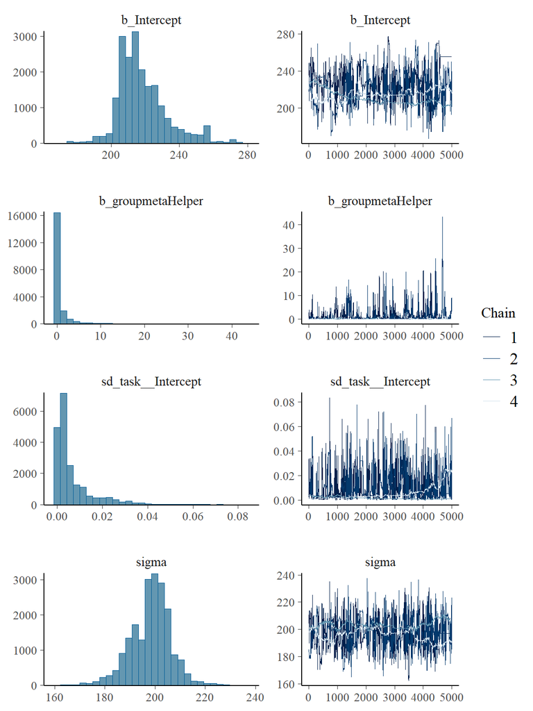

```r
plot(result_time_all_removed1)
```